# CF-genérico

Lívia Cavalcanti

20 de dezembro de 2017

## Bibliotecas utilizadas

Utilizou-se as mesmas bibliotecas do programa anterior. Sendo elas:

```r
library(dplyr)
library(corrplot)
library(GGally)
library(ggplot2)
library(reshape2)
library(caret)
library(hydroGOF)
```

## Os dados

Estão sendo utilizados os dados dos estudantes de Computação da UFCG, assim como anteriormente, e está sendo feito o mesmo tratamento dos dados. Em resumo, são considerados os estudantes que concluíram o curso, ou seja, tem-se todas as notas de cada um, sendo considerada apenas a nota que o estudante passou em cada cadeira, tratada no código como a maior nota do aluno naquela disciplina.

```r
dados_alunos <- read.csv("../alunosUFCGAnon.csv")
dados_aluno_cc <- dados_alunos %>% filter(Cod_Curso == 14102100 & Cod_Evasao == 0 & Tipo == "Obrigatória")
dados_aluno_cc <- dados_aluno_cc %>% mutate(Matricula = factor(Matricula)) %>% arrange(Matricula) %>%
  select(Matricula, Cod_Disciplina, Nome_Disciplina, Periodo, Creditos, Media_Disciplina, Situacao, Periodo_Ingresso, Periodo_Relativo)
dados_aluno_cc <- dados_aluno_cc %>% group_by(Matricula) %>% mutate(Media = round(mean(Media_Disciplina), digits = 2)) %>% filter(!is.na(Media))

# Calulo do CRA
alunos_cra <- dados_aluno_cc %>% mutate(Cra.Crontibute = Media*Creditos) %>% summarise(cra = sum(Cra.Crontibute)/sum(Creditos))
alunos_max_media <- dados_aluno_cc %>% group_by(Matricula, Nome_Disciplina) %>% filter(Media_Disciplina == max(Media_Disciplina)) %>% ungroup() %>%
  select(Nome_Disciplina, Matricula, Media_Disciplina) %>% mutate(Nome_Disciplina = as.factor(gsub(" ", ".", Nome_Disciplina))) %>%
  dcast(Matricula ~ Nome_Disciplina, mean) %>% merge(alunos_cra)
alunos_max_media <- bind_cols(alunos_max_media,distinct(dados_aluno_cc %>% select(Matricula, Periodo_Ingresso))%>% select(Periodo_Ingresso)) %>%
  select(-Matricula1) %>% na.omit()
# Alunos que possuem todas as notas
alunos_graduados <- alunos_max_media[complete.cases(alunos_max_media), ]
head(alunos_graduados)
```

```
##    Matricula ALGEBRA.LINEAR.I ÁLGEBRA.VETORIAL.E.GEOMETRIA.ANALÍTICA
## 4     B10092              6.1                                    6.4
## 21    B10504              5.0                                    6.3
## 41    B11044              9.3                                    8.6
## 60    B11671              5.9                                    6.5
## 66    B11776              7.0                                    9.4
## 92    B12263              9.0                                   10.0
##    ANÁLISE.E.TÉCNICA.DE.ALGORITMOS
## 4                              7.0
## 21                             8.0
## 41                             8.7
## 60                             7.7
## 66                             8.1
## 92                             9.5
##    AVAL.DE.DESEMPENHO.DE.SISTEMAS.DISCRETOS BANCO.DE.DADOS.I
```

[output cut: 139 more lines]

É preciso listar todas as cadeiras de interesse, aqui, todas as cadeiras do curso separadas por período.

```r
PRIMEIRO_PER <- list("CALCULO.DIFERENCIAL.E.INTEGRAL.I","ÁLGEBRA.VETORIAL.E.GEOMETRIA.ANALÍTICA","PROGRAMAÇÃO.I",
                     "LABORATÓRIO.DE.PROGRAMAÇÃO.I","INTRODUÇÃO.A.COMPUTAÇÃO","LEITURA.E.PRODUCAO.DE.TEXTOS")
SEGUNDO_PER <- list("METODOLOGIA.CIENTÍFICA", "FUNDAMENTOS.DE.FÍSICA.CLÁSSICA", "CALCULO.DIFERENCIAL.E.INTEGRAL.II",
                    "MATEMÁTICA.DISCRETA", "PROGRAMAÇÃO.II", "TEORIA.DOS.GRAFOS","LABORATÓRIO.DE.PROGRAMAÇÃO.II")
TERCEIRO_PER <- list("ALGEBRA.LINEAR.I", "FUNDAMENTOS.DE.FÍSICA.MODERNA", "TEORIA.DA.COMPUTAÇÃO", "ESTRUTURA.DE.DADOS.E.ALGORITMOS",
                     "GERÊNCIA.DA.INFORMAÇÃO", "LAB.DE.ESTRUTURA.DE.DADOS.E.ALGORITMOS", "PROBABILIDADE.E.ESTATISTICA")
QUARTO_PER <- list("METODOS.ESTATISTICOS","PARADIGMAS.DE.LING..DE.PROGRAMAÇÃO", "LÓGICA.MATEMÁTICA", "ORG.E.ARQUITETURA.DE.COMPUTADORES.I",
                   "ENGENHARIA.DE.SOFTWARE.I","SISTEMAS.DE.INFORMAÇÃO.I","LAB.DE.ORG.E.ARQUITETURA.DE.COMPUTADORES")
QUINTO_PER <- list("INFORMÁTICA.E.SOCIEDADE", "LABORATÓRIO.DE.ENGENHARIA.DE.SOFTWARE", "ANÁLISE.E.TÉCNICA.DE.ALGORITMOS",
                   "COMPILADORES", "REDES.DE.COMPUTADORES", "BANCO.DE.DADOS.I", "SISTEMAS.DE.INFORMAÇÃO.II")
SEXTO_PER <- list("DIREITO.E.CIDADANIA", "LAB.DE.INTERCON.DE.REDES.DE.COMPUTADORES", "INTERCONEXÃO.DE.REDES.DE.COMPUTADORES",
                  "SISTEMAS.OPERACIONAIS", "BANCO.DE.DADOS.II","INTELIGENCIA.ARTIFICIAL.I")
SETIMO_PER <- list("PROJETO.EM.COMPUTAÇÃO.I", "MÉTODOS.E.SOFTWARE.NUMÉRICOS", "AVAL.DE.DESEMPENHO.DE.SISTEMAS.DISCRETOS")
OITAVO_PER <- list("PROJETO.EM.COMPUTAÇÃO.II")
```

Elas são agrupadas em uma lista de listas para que o cálculo possa ser realizado sobre cada uma delas e considerando suas anteriores de forma mais automatizada.

```r
lista_periodos <- list(PRIMEIRO_PER, SEGUNDO_PER, TERCEIRO_PER, QUARTO_PER, QUINTO_PER,SEXTO_PER, SETIMO_PER, OITAVO_PER)
lista_periodos
```

```
## [[1]]
## [[1]][[1]]
## [1] "CALCULO.DIFERENCIAL.E.INTEGRAL.I"
##
## [[1]][[2]]
## [1] "ÁLGEBRA.VETORIAL.E.GEOMETRIA.ANALÍTICA"
##
## [[1]][[3]]
## [1] "PROGRAMAÇÃO.I"
##
## [[1]][[4]]
## [1] "LABORATÓRIO.DE.PROGRAMAÇÃO.I"
##
## [[1]][[5]]
## [1] "INTRODUÇÃO.A.COMPUTAÇÃO"
##
## [[1]][[6]]
## [1] "LEITURA.E.PRODUCAO.DE.TEXTOS"
##
##
## [[2]]
## [[2]][[1]]
## [1] "METODOLOGIA.CIENTÍFICA"
##
## [[2]][[2]]
## [1] "FUNDAMENTOS.DE.FÍSICA.CLÁSSICA"
##
## [[2]][[3]]
## [1] "CALCULO.DIFERENCIAL.E.INTEGRAL.II"
##
## [[2]][[4]]
## [1] "MATEMÁTICA.DISCRETA"
##
## [[2]][[5]]
## [1] "PROGRAMAÇÃO.II"
##
## [[2]][[6]]
## [1] "TEORIA.DOS.GRAFOS"
##
## [[2]][[7]]
```

[output cut: 91 more lines]

```
##
## [[7]]
## [[7]][[1]]
## [1] "PROJETO.EM.COMPUTAÇÃO.I"
##
## [[7]][[2]]
## [1] "MÉTODOS.E.SOFTWARE.NUMÉRICOS"
##
## [[7]][[3]]
## [1] "AVAL.DE.DESEMPENHO.DE.SISTEMAS.DISCRETOS"
##
##
## [[8]]
## [[8]][[1]]
## [1] "PROJETO.EM.COMPUTAÇÃO.II"
```

## Funções e constantes

As constantes utilizadas nesse código são relativas a quantidade de vizinhos a serem utilizados no cálculo do score(‘K’) que foi calculado em outro código; a similaridade necessária para que dois indivíduos sejam considerados como vizinhos(‘NEIGH’), a quantidade de alunos utilizada para o teste(‘N_ALUNOS’), esta dependerá da porcentagem da amostra definida para teste e da quantidade de dados, nesse caso ela tem valor 4; e o número máximo de disciplinas cursadas num período(N_DISC), para que os dados sejam armazenados corretamente.

```r
K = 3
NEIGH = 0.7
N_ALUNOS = 4
N_DISC = 7
```

As funções também já são conhecidas: ‘get_sim’ retorna a similaridade entre todos os aluno; ‘get_neigh’, os ‘K’ alunos mais semelhantes de acordo com ‘NEIGH’; e ‘get_score’ que calcula as notas preditas.

```r
get_sim <- function(df) {

  row.names(df) <- df$Matricula
  df <- df %>% subset(select=-c(Matricula))

  inv_df <- as.data.frame(t(df))

  res <- cor(inv_df[sapply(inv_df, is.numeric)], use="p", method='pearson')
  return(res);
}

# retorna um vector de Named num, cujo nome é a matrícula e o valor a similaridade
get_neigh <- function(df, index, corr) {

  matr <- (df[index, 1])

  # todos os vizinhos, porém temos que "invalidar" ele mesmo
  corr[as.double(matr), as.double(matr)] = 0
  all_neigh <- corr[matr, ]

  k_neigh <- sort(all_neigh, decreasing = T)[1:K]

  return(k_neigh);
}

# calcula score ignorando vizinhos com NAs
get_score <- function(df, k_neigh, item) {

  notas <- subset(df, Matricula %in% names(k_neigh))

  # removendo vizinhos que não possuem notas
  notas <- na.omit(notas)

  # se todas as notas dos vizinhos forem NAs ou nenhum vizinho com
  # nota tenha similaridade > NEIGH consideramos que esse aluno
  # não tem vizinhos
  if(nrow(notas) == 0) {
    return(NA)
  }

  # atualizando similaridade
  notas$sim <- 0
  for(i in 1:length(notas$Matricula)) {
    notas$sim[i] <- k_neigh[as.character(notas$Matricula[i])]
  }

  # se todas as notas dos vizinhos forem NAs ou nenhum vizinho com
  # nota tenha similaridade > NEIGH consideramos que esse aluno
  # não tem vizinhos
  eh_valido <- notas[notas$sim > NEIGH,]
  if(nrow(eh_valido) == 0) {
    return(NA)
  }

  # print(item)
  # print(notas[, item])
  # print(sum(notas[, item] * notas$sim) / sum(notas$sim))

  res <- sum(notas[, item] * notas$sim) / sum(notas$sim)
  return(res)
}
```

Os dados são separados em dados de treino(90%) e teste. É criado um data frame para que sejam guardadas as médias de RMSE por período. Um data frame para guardar o RMSE de cada estudante da amostra de teste para cada respectiva discplina e a média geral desse RMSE por aluno. Para que o cálculo de similaridade seja bem sucedido foi preferido reenumerar as matrículas, a fim de que elas representem mais facilmente a posição do aluno no data frame. Foram retirados o CRA e o Período de Ingresso, pois não eram dados que fazia sentido usar na predição. São guardados as notas reais dos alunos para que posteriormente seja feita a comparação e o cálculo do erro.

```r
# separando em teste e treino
temp <- createDataPartition(alunos_graduados$Periodo_Ingresso, p = 0.90, list = F)
temp
```

```
##       Resample1
##  [1,]         1
##  [2,]         2
##  [3,]         3
##  [4,]         4
##  [5,]         5
##  [6,]         6
##  [7,]         7
##  [8,]         8
##  [9,]         9
## [10,]        10
## [11,]        11
## [12,]        12
## [13,]        13
## [14,]        14
```

[output cut: 41 more lines]

```r
rmse_periodo <- as.data.frame(matrix(NA, nrow = 7))

#data frame onde serão guardadas as predições
predicao_geral <- as.data.frame(matrix(ncol = 7))
media_rmse <- c(NA)
predicao_geral <- cbind(predicao_geral, as.data.frame(media_rmse))

#notas de todas as cadeiras de todos os alunos
dados_treino2 <- alunos_graduados %>% mutate(Matricula = 1:59) %>% select(-cra, - Periodo_Ingresso)
head(dados_treino2)
```

```
##   Matricula ALGEBRA.LINEAR.I ÁLGEBRA.VETORIAL.E.GEOMETRIA.ANALÍTICA
## 1         1              6.1                                    6.4
## 2         2              5.0                                    6.3
## 3         3              9.3                                    8.6
## 4         4              5.9                                    6.5
## 5         5              7.0                                    9.4
## 6         6              9.0                                   10.0
##   ANÁLISE.E.TÉCNICA.DE.ALGORITMOS AVAL.DE.DESEMPENHO.DE.SISTEMAS.DISCRETOS
## 1                             7.0                                      8.1
## 2                             8.0                                      5.0
## 3                             8.7                                      8.7
## 4                             7.7                                      8.9
## 5                             8.1                                      7.1
## 6                             9.5                                      9.5
##   BANCO.DE.DADOS.I BANCO.DE.DADOS.II CALCULO.DIFERENCIAL.E.INTEGRAL.I
```

[output cut: 132 more lines]

```r
resultados2 <- dados_treino2[-temp,]
resultados2
```

```
##    Matricula ALGEBRA.LINEAR.I ÁLGEBRA.VETORIAL.E.GEOMETRIA.ANALÍTICA
## 17        17              6.8                                    8.8
## 42        42              8.0                                    8.8
## 47        47              6.2                                    5.6
## 51        51              8.2                                    8.5
##    ANÁLISE.E.TÉCNICA.DE.ALGORITMOS
## 17                             5.4
## 42                             7.2
## 47                             8.1
## 51                             8.1
##    AVAL.DE.DESEMPENHO.DE.SISTEMAS.DISCRETOS BANCO.DE.DADOS.I
## 17                                      8.9              7.4
## 42                                      8.5              6.4
## 47                                      8.7              9.0
## 51                                      8.4              9.0
```

[output cut: 95 more lines]

## Predição

O algoritmo desenvolvido é, claramente, pouco eficiente devido a sua estrutura, mas dada a quantidade de dados considerada ele não, por exemplo, demora na execução, sendo, portanto, viável. Ele calcula a predição para as disciplinas de cada período a partir do segundo, já que no primeiro não há dados para fazê-lo. São guardadas as disciplinas para as quais se quer que as notas sejam preditas e as disciplinas que ajudarão na predição. As que se deseja calcular são transformadas em NA a fim de que não influenciem, por exemplo, no cálculo de correlação(‘get_sim’). São guardados os dados de teste que possuem as notas dos alunos nos períodos anteriores ao que analisado e a nota das cadeiras no período atual como NA. Outra variável contém os valores das linhas dos alunos de teste. Feito isso, para cada aluno ao qual se deseja fazer uma predição são calculados os vizinhos mais próximos e, com base nestes, é calculada sua nota para cada cadeira do período atual. Por fim, acontece o cálculo do RMSE, de sua média para cada aluno e da amostra, sendo o último considerado o RMSE do período. Todos os dados são guardados em data frames.

```r
for(disciplinas_periodo in 2:length(lista_periodos)){
  # cadeiras que serao usadas no calculo
  indices_da_vez <- unlist(lista_periodos[1:disciplinas_periodo])
  treino_valores2 <-  dados_treino2 %>% select(Matricula,indices_da_vez) %>% na.omit()
  cadeiras_atuais <- unlist(lista_periodos[disciplinas_periodo])

  for(l in 1:lengths(lista_periodos[disciplinas_periodo])) {
    treino_valores2[-temp,][cadeiras_atuais[l]] <- NA
  }


  teste_valores2 <- treino_valores2[-temp,]
  teste_indices2 <- rownames(teste_valores2)
  # calculando a correlacao entre os alunos que jah pagaram a cadeira e os que nós queremos calcular
  corr <- treino_valores2 %>% get_sim()

  for(m in 1:length(teste_indices2)) {
    index <- teste_indices2[m]
    k_proximos <- get_neigh(teste_valores2, index, corr)
    for(j in 1:length(cadeiras_atuais)) {
      pred <- get_score(treino_valores2[, c("Matricula", cadeiras_atuais[j])],
                        k_proximos, cadeiras_atuais[j])
      teste_valores2[index, cadeiras_atuais[j]] <- pred
    }
  }

  # simplificando os dados
  dados_reais2 <- alunos_graduados[-temp,cadeiras_atuais]
  predicao2 <- teste_valores2[, cadeiras_atuais]

  # conversão para quando dados_reais e predicao foram vetores e nao data.frames, a fim de se evitar erro no for seguinte
  if(class(predicao2) == "numeric"){
    predicao2 <- as.data.frame(predicao2)
  }

  if(class(dados_reais2) == "numeric"){
    dados_reais2 <- as.data.frame(dados_reais2)
  }

  erro_rmse <- as.data.frame(matrix(0, nrow = N_ALUNOS, ncol = N_DISC))
  for(aluno in 1:(N_ALUNOS)){
    for(cadeira in 1:length(cadeiras_atuais)) {
      erro_rmse[aluno,cadeira] <- (rmse(sim=predicao2[aluno,cadeira], obs=dados_reais2[aluno,cadeira]))
    }
  }

  erro_rmse <- as.data.frame(erro_rmse) %>%
    mutate(media_rmse = rowMeans(as.data.frame(erro_rmse)[,1:7]))
  rmse_periodo[disciplinas_periodo,] <- mean(as.data.frame(erro_rmse %>% select(media_rmse) %>% na.omit())$media_rmse)
  predicao_geral <- rbind(predicao_geral, erro_rmse)

}
```

## Olhando os resultados

```r
rmse_periodo
```

[output not shown]

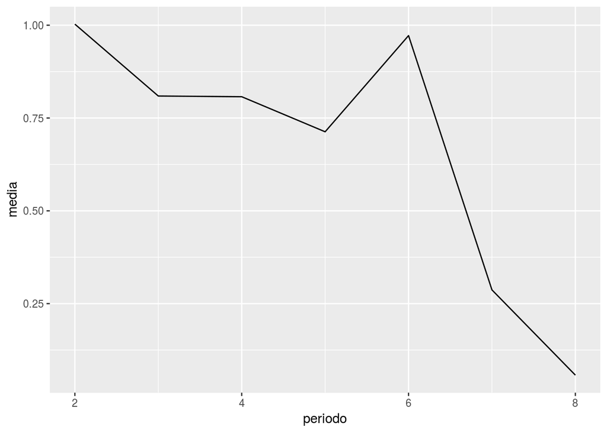

```r
rmse_periodo %>% ggplot(aes(periodo, media)) + geom_line()
```